# ATD2022_Ficha4_Matlab

### Ficha Prática nº 4 de ATD 2022

Alberto Cardoso ©DEI2021/2022

Objetivo: Pretende-se adquirir sensibilidade para as questões fundamentais de sinais e sistemas, em particular para as propriedades de sinais e de sistemas lineares em tempo discreto, como a linearidade, a invariância e a resposta a impulso.

**Exercício 1.** Implementar um script em Matlab que receba um sinal x[n] e devolva a resposta do sistema caracterizado pela seguinte equação de diferenças: $y[n]=b_0x[n]+b_1 x[n-1]+b_2 x[n-2]+b_3 x[n-3]+b_4 x[n-4]$, em que: $b_0=0.1(mod(PL\#,2)+1)$, $b_1=0.4 mod(PL\#,2)$, $b_2=0.4 mod(1+PL\#,2)$, $b_3=0.3(mod(PL\#,3)+1)$, $b_4=-0.1(mod(PL\#,4)+1)$

**Exercício 1.1** Definindo, através duma função, o sinal $x[n]=1.5 sin[0.025πn](u[n+40]-u[n-40])$, em que o sinal $u[n-m]$ é um degrau unitário que tem o valor 0 para $n < m$ e o valor 1 para $n ≥ m$, obter e representar graficamente o sinal de entrada $x[n]$ e a resposta do sistema, $y[n]$, para $-50≤n<50$.

```matlab
%%file entrada.m

% função que define um dado sinal de tempo discreto
function x=entrada(n)
x=zeros(size(n));
ind=find((n>=-40) & (n<40));
x(ind)=1.5*sin(0.025*pi*n(ind));
```

```
b =

    0.1000         0    0.4000    0.9000   -0.3000
```

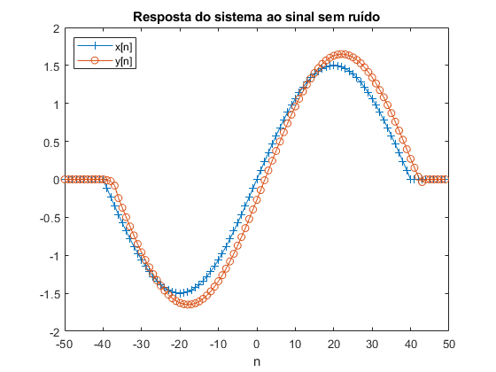

```matlab
%--- Ex 1.1
% Resolução numérica
%plot inline -w 1200

% PL=input('Turma PL: ');
PL = 2;
b0=0.1*(mod(PL,2)+1);
b1=0.4*(mod(PL,2));
b2=0.4*(mod(1+PL,2));
b3=0.3*(mod(PL,3)+1);
b4=-0.1*(mod(PL,4)+1);
b=[b0 b1 b2 b3 b4]

n=-50:49;
m=-54:49;   % tempo discreto com a memória necessária para o sistema
% m = [-54 -53 -52 -51 -50 -49 ... 49]
% x[n]  -50<= n <50
% x[n-1]   -51<= n <49
x=entrada(m);
y=b0*x(5:end)+b1*x(4:end-1)+b2*x(3:end-2)+...
    b3*x(2:end-3)+b4*x(1:end-4);

figure()
plot(n,x(5:end),'-+',n,y,'-o')
xlabel('n');
title('Resposta do sistema ao sinal sem ruído');
legend('x[n]','y[n]','Location','northwest')
```

```
b =

    0.1000         0    0.4000    0.9000   -0.3000
```

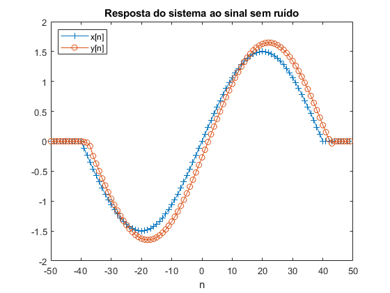

```matlab
%--- Ex 1.1
% Resolução simbólica
oldparam = sympref('HeavisideAtOrigin',1);
syms n

% PL=input('Turma PL: ');
PL = 2;
b0=0.1*(mod(PL,2)+1);
b1=0.4*(mod(PL,2));
b2=0.4*(mod(1+PL,2));
b3=0.3*(mod(PL,3)+1);
b4=-0.1*(mod(PL,4)+1);
b=[b0 b1 b2 b3 b4]

xns=(1.5*sin(0.025*pi*n))*(heaviside(n+40)-heaviside(n-40));
yns=b0*xns+b1*subs(xns,n-1)+b2*subs(xns,n-2)+...
    b3*subs(xns,n-3)+b4*subs(xns,n-4);

n=-50:49;
xn=double(subs(xns));
yn=double(subs(yns));

figure()
plot(n,xn,'-+',n,yn,'-o')
xlabel('n');
title('Resposta do sistema ao sinal sem ruído');
legend('x[n]','y[n]','Location','northwest')
```

**Exercício 1.2** Adicionar ao sinal $x[n]$, definido em 1.1, ruído uniforme com amplitude no intervalo $[-0.2,0.2]$. Utilize a função *rand* do Matlab. Obter e representar graficamente o sinal de entrada $x[n]$ com ruído e a correspondente resposta do sistema, $y[n]$, para $-50≤n<50$.

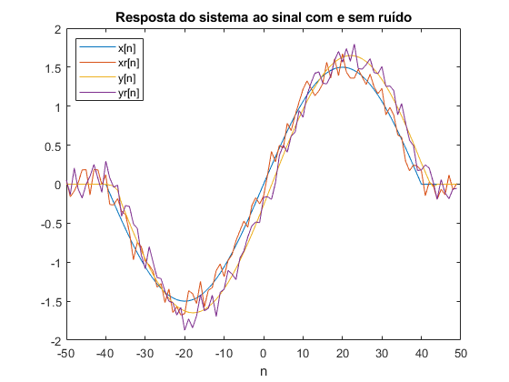

```matlab
%--- Ex 1.2
% Resolução numérica

xr=x+0.4*rand(size(x))-0.2;

yr=b0*xr(5:end)+b1*xr(4:end-1)+b2*xr(3:end-2)+...
    b3*xr(2:end-3)+b4*xr(1:end-4);

figure();
plot(n,x(5:end),n,xr(5:end),n,y,n,yr)
xlabel('n');
title('Resposta do sistema ao sinal com e sem ruído');
legend('x[n]','xr[n]','y[n]','yr[n]','Location','northwest')
```

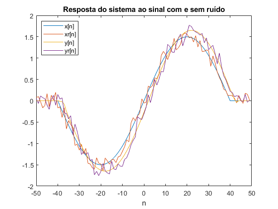

```matlab
%--- Ex 1.2
% Resolução simbólica
syms n
xns=(1.5*sin(0.025*pi*n))*(heaviside(n+40)-heaviside(n-40));
m=-54:49;
xrn=double(subs(xns,m))+0.4*rand(size(m))-0.2;

yrn=b0*xrn(5:end)+b1*xrn(4:end-1)+b2*xrn(3:end-2)+...
    b3*xrn(2:end-3)+b4*xrn(1:end-4);

figure();
plot(m(5:end),xn,m(5:end),xrn(5:end),...
    m(5:end),yn,m(5:end),yrn)
xlabel('n');
title('Resposta do sistema ao sinal com e sem ruído');
legend('x[n]','xr[n]','y[n]','yr[n]','Location','northwest')
```

**Exercício 1.3** Comparar, analisar e comentar os resultados obtidos em 1.1 e em 1.2.

```matlab
% A adição de ruído ao sinal de entrada do sistema refletiu-se na
% sua saída e é, neste caso, amplificado tal como o sinal original
```

**Exercício 2.** Considerar o sinal de tempo discreto $x[n]=1.5 sin[ 0.025πn](u[n+40]-u[n-40])$, o sistema $y1[n]$, dado pela equação de diferenças $y[n]$, e os seguintes sistemas de tempo discreto:

$y_2 [n]=0.6x[2n-4]$;

$y_3 [n]=0.5x[n-2]x[n-3]$;

$y_4 [n]=(n-2)x[n-3]$.

**Exercício 2.1** Determinar e apresentar a resposta dos sistemas ao sinal de entrada $x[n]$, para $-50≤n≤50$.

```matlab
%%file transf_lin.m

% transformação linear da variável independente
% de um sinal de tempo discreto

function [m,y]=transf_lin(x, n, a, b)

mt=(n+b)/a;				% escala alterada

x1=x(mod(mt,1)==0);		% sinal nos pontos (inteiros) da nova escala

m1=mt(mod(mt,1)==0);    % tempo discreto (só com inteiros)

m=min(m1):max(m1);		% escala temporal normalizada

y(m1-min(m1)+1)=x1;     % sinal resultante de acordo com escala normalizada
```

**Exercício 2.2** Analisar a linearidade dos sistemas dados por $y1[n]$, $y2[n]$, $y3[n]$ e $y4[n]$.

```matlab
%--- Ex 2.2
% Verificar a linearidade dos sistemas recorrendo ao cálculo simbólico

syms n x1(n) x2(n) a

assume(n,'integer');

% Verificar a linearidade do sistema dado por y1[n]

y11n=b0*x1(n)+b1*x1(n-1)+b2*x1(n-2)+b3*x1(n-3)+b4*x1(n-4);
y12n=b0*x2(n)+b1*x2(n-1)+b2*x2(n-2)+b3*x2(n-3)+b4*x2(n-4);
y1a1a2n=b0*a*(x1(n)+x2(n))+b1*a*(x1(n-1)+x2(n-2))+ ...
b2*a*(x1(n-2)+x2(n-2))+b3*a*(x1(n-3)+x2(n-3))+b4*a*(x1(n-4)+x2(n-4));

y1cn=a*(y11n+y12n);

if simplify(expand(y1cn))==simplify(expand(y1a1a2n))
disp('y1[n] é Linear')
else disp('y1[n] é Não linear')
end

% Verificar a linearidade do sistema dado por y2[n]

y21n=0.6*x1(2*n-4);
y22n=0.6*x2(2*n-4);
y2a1a2n=0.6*a*(x1(2*n-4)+x2(2*n-4));

y2cn=a*(y21n+y22n);

if simplify(expand(y2cn))==simplify(expand(y2a1a2n))
disp('y2[n] é Linear')
else disp('y2[n] é Não linear')
end

% Verificar a linearidade do sistema dado por y3[n]

y31n=0.5*x1(n-2)*x1(n-3);
y32n=0.6*x2(n-2)*x2(n-3);
y3a1a2n=0.6*a*(x1(n-2)+x2(n-2))*a*(x1(n-3)+x2(n-3));

y3cn=a*(y31n+y32n);

if simplify(expand(y3cn))==simplify(expand(y3a1a2n))
disp('y3[n] é Linear')
else disp('y3[n] é Não linear')
end

% Verificar a linearidade do sistema dado por y4[n]

y41n=(n-2)*x1(n-3);
y42n=(n-2)*x2(n-3);
y4a1a2n=(n-2)*a*(x1(n-3)+x2(n-3));

y4cn=a*(y41n+y42n);

if simplify(expand(y4cn))==simplify(expand(y4a1a2n))
disp('y4[n] é Linear')
else disp('y4[n] é Não linear')
end
```

```
y1[n] é Linear
y2[n] é Linear
y3[n] é Não linear
y4[n] é Linear
```

**Exercício 2.3** Analisar a Invariância no tempo dos sistemas dados por $y1[n]$, $y2[n]$, $y3[n]$ e $y4[n]$.

```matlab
%--- Ex 2.3

% y1[n] é invariante no tempo
% y2[n] é variante no tempo
% y3[n] é invariante no tempo
% y4[n] é variante no tempo
```

**Exercício 2.4** Determinar a expressão e representar graficamente a resposta a impulso do sistema $h1[n]$.

```
b =

    0.1000         0    0.4000    0.9000   -0.3000
```

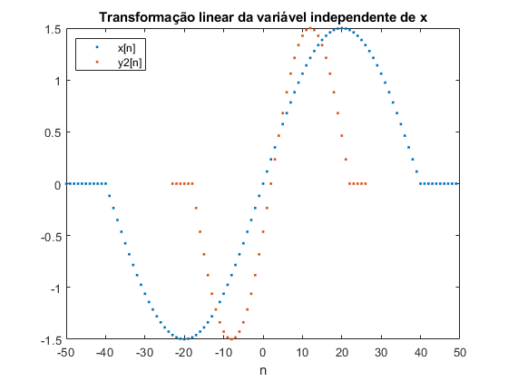

```matlab
%--- Ex 2.4
% Obtenção da saída do sistema y2[n]
%PL=input('Turma PL: ');
PL=2;
b0=0.1*(mod(PL,2)+1);
b1=0.4*(mod(PL,2));
b2=0.4*(mod(1+PL,2));
b3=0.3*(mod(PL,3)+1);
b4=-0.1*(mod(PL,4)+1);
b=[b0 b1 b2 b3 b4]

n=-50:49;
m=-54:49;   % tempo discreto com a memória necessária para o sistema
x=entrada(m);
y1=b0*x(5:end)+b1*x(4:end-1)+b2*x(3:end-2)...
    +b3*x(2:end-3)+b4*x(1:end-4);

[n_transf,x_transf]=transf_lin(x(5:end),n, 2, 4);

figure()
subplot;
plot(n,x(5:end),'.',n_transf,x_transf,'.')
title('Transformação linear da variável independente de x');
xlabel('n');
legend('x[n]','y2[n]','Location','northwest')
```

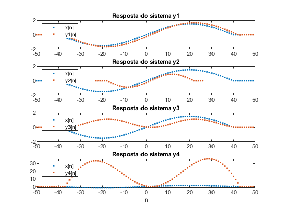

```matlab
%--- Ex 2.4

y2=0.6*x_transf;

y3=0.5*x(3:end-2).*x(2:end-3);

y4=m(3:end-2).*x(2:end-3);

figure()
subplot(411)
plot(n,x(5:end),'.',n,y1,'.')
title('Resposta do sistema y1');
legend('x[n]','y1[n]','Location','northwest')
subplot(412)
plot(n,x(5:end),'.',n_transf,y2,'.')
title('Resposta do sistema y2');
legend('x[n]','y2[n]','Location','northwest')
subplot(413)
plot(n,x(5:end),'.',n,y3,'.')
title('Resposta do sistema y3');
legend('x[n]','y3[n]','Location','northwest')
subplot(414)
plot(n,x(5:end),'.',n,y4,'.')
title('Resposta do sistema y4');
xlabel('n');
legend('x[n]','y4[n]','Location','northwest')
```

**Exercício 2.5** Com base na resposta a impulso do sistema $h1[n]$, determinar a saída do sistema para o sinal de entrada $x[n]$.

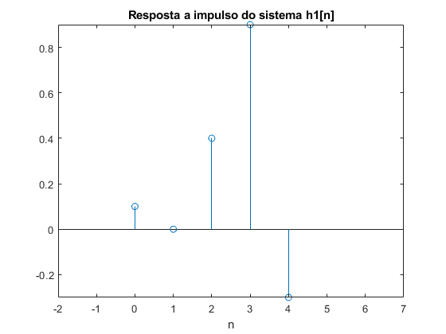

```matlab
%--- Ex 2.5

h1=b;   % Resposta a impulso do sistema, h[n]

figure()
stem(0:length(h1)-1,h1)
axis([-2 length(h1)+2 min(h1) max(h1)])
title('Resposta a impulso do sistema h1[n]');
xlabel('n');
```

**Exercício 2.6** Representar graficamente os sinais de entrada e de saída considerados em 2.5, para $-50≤n≤50$.

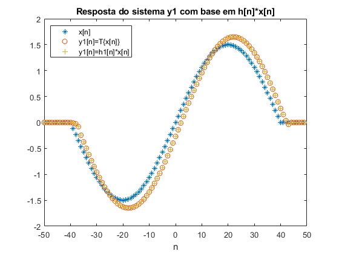

```matlab
%--- Ex 1.2

yh1=conv(h1,x(5:end)); % Convolução y[n]=h[n]*x[n]
yh1=yh1(1:end-length(h1)+1); % ajuste da dimensão da saída

figure()
stairs(n,double(x(5:end)),'*');
hold on
stairs(n,y1,'o')
stairs(n,yh1,'+')
hold off
title('Resposta do sistema y1 com base em h[n]*x[n]');
xlabel('n');
legend('x[n]','y1[n]=T\{x[n]\}','y1[n]=h1[n]*x[n]','Location','northwest')
```